# More charts

Andrew Ba Tran

This is from the [fourth chapter](http://learn.r-journalism.com/en/visualizing/more_charts/fancy-charts/) of [learn.r-journalism.com](https://learn.r-journalism.com/).

We’re going to go over some examples of visualizations created with packages that people have created to build on top of **ggplot2**. People love improving and building upon things. The latest version of **ggplot2** was released recently and more than [300 people contributed](https://twitter.com/hadleywickham/status/1014514026208989185)– either by adding pieces from their add-on packages or by suggesting fixes.

## gghighlight

The **gghighlight** package is a relatively new addition. In the previous section, I showed a way to surface important data while keeping the background data for context. This package simplifies it. Learn more on [their site](https://cran.r-project.org/web/packages/gghighlight/vignettes/gghighlight.html).

We’ll use historical monthly average temperature data from the [National Centers for Environmental Information](https://www.ncdc.noaa.gov/cag/national/time-series/110/tavg/all/5/1895-2018?base_prd=true&firstbaseyear=1901&lastbaseyear=2000&trend=true&trend_base=10&firsttrendyear=1895&lasttrendyear=2018).

This is the image they have on their site illustrating their data:

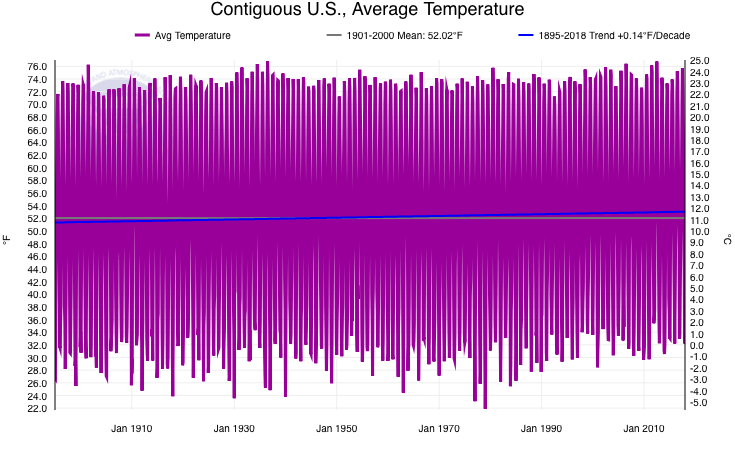

We can do better.

Start with importing and transforming the data below:

```r
# If you don't have readr installed yet, uncomment and run the line below
# install.packages("readr")

library(readr)

temps <- read_csv("data/110-tavg-all-5-1895-2018.csv", skip=4)
head(temps)
```

```
## # A tibble: 6 x 3
##     Date Value Anomaly
##    <int> <dbl>   <dbl>
## 1 189501  26.7   -3.43
## 2 189502  26.6   -7.22
## 3 189503  40.0   -1.53
## 4 189504  52.9    1.85
## 5 189505  59.9   -0.26
## 6 189506  67.8   -0.69
```

```r
# If you don't have readr installed yet, uncomment and run the line below
# install.packages("lubridate")

library(lubridate)

# Converting the date into a date format R recognizes
# This requires using paste0() to add a day to the date, so 189501 turns into 18950101

temps$Date <- ymd(paste0(temps$Date, "01"))

# Extracting the year
temps$Year <- year(temps$Date)

# Extracting the month
temps$month <- month(temps$Date)
temps$month <- as.numeric(temps$month)
temps$month_label <- month(temps$Date, label=T)

# Creating a column with rounded numbers
temps$rounded_value <- round(temps$Value, digits=0)

# Turning the year into a factor so it'll chart easier
temps$Year <- as.factor(as.character(temps$Year))


head(temps)
```

```
## # A tibble: 6 x 7
##   Date       Value Anomaly Year  month month_label rounded_value
##   <date>     <dbl>   <dbl> <fct> <dbl> <ord>               <dbl>
## 1 1895-01-01  26.7   -3.43 1895      1 Jan                    27
## 2 1895-02-01  26.6   -7.22 1895      2 Feb                    27
## 3 1895-03-01  40.0   -1.53 1895      3 Mar                    40
## 4 1895-04-01  52.9    1.85 1895      4 Apr                    53
## 5 1895-05-01  59.9   -0.26 1895      5 May                    60
## 6 1895-06-01  67.8   -0.69 1895      6 Jun                    68
```

Now we have some tidy data to visualize.

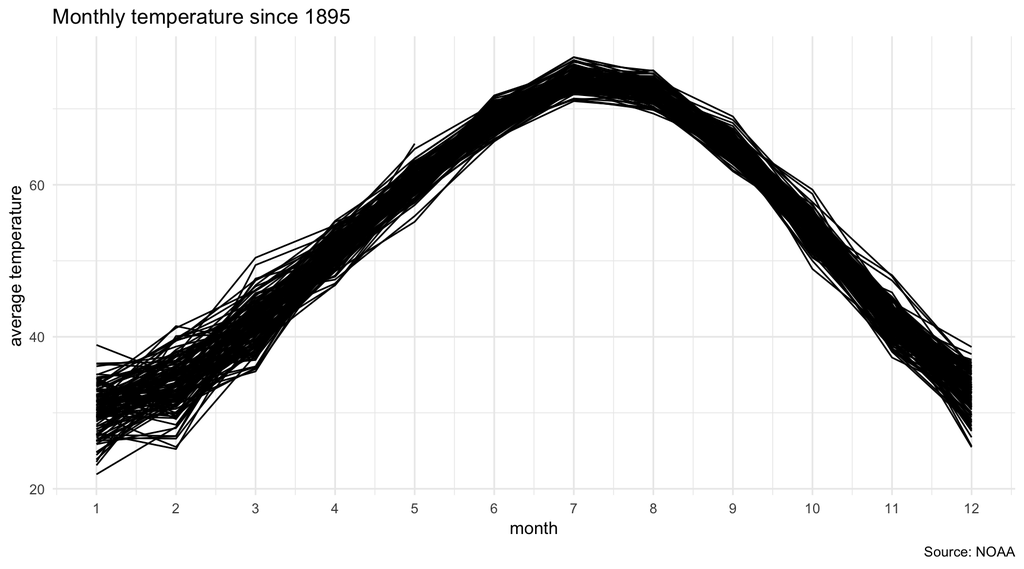

```r
# If you don't have readr installed yet, uncomment and run the line below
# install.packages("ggplot2")

library(ggplot2)

ggplot(temps, aes(x=month, y=Value, group=Year)) +
  geom_line() +
  scale_x_continuous(breaks=seq(1,12,1), limits=c(1,12)) +
  theme_minimal() +
  labs(y="average temperature", title="Monthly temperature since 1895", caption="Source: NOAA")
```

Let’s use the **gghighlight** package to make this clearer to readers.

```
## label_key: Year
```

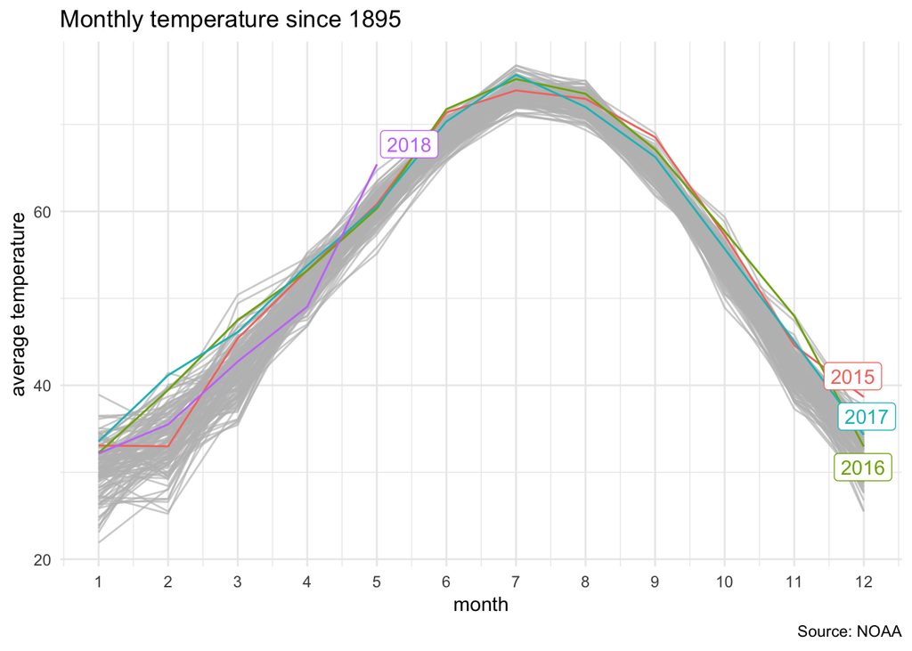

```r
# If you don't have readr installed yet, uncomment and run the line below
# install.packages("gghighlight")

library(gghighlight)

ggplot(temps, aes(x=month, y=Value, color=Year)) +
  geom_line() +
  scale_x_continuous(breaks=seq(1,12,1), limits=c(1,12)) +
  theme_minimal() +
  labs(y="average temperature", title="Monthly temperature since 1895", caption="Source: NOAA") +
  # NEW CODE BELOW
  gghighlight(max(as.numeric(Year)), max_highlight = 4L)
```

## ggrepel

Did you like those labels for years on the chart?

That comes from the [**ggrepel**](https://cran.r-project.org/web/packages/ggrepel/vignettes/ggrepel.html) package. The `geom_label_repel()` lets you add those button labels to charts and, as the name implies, it makes sure the labels do not collide or stack on top of each other.

Let’s take a look at the dataframe from the first ggplot section.

We’ll make a labeled chart with **ggplot2** as is.

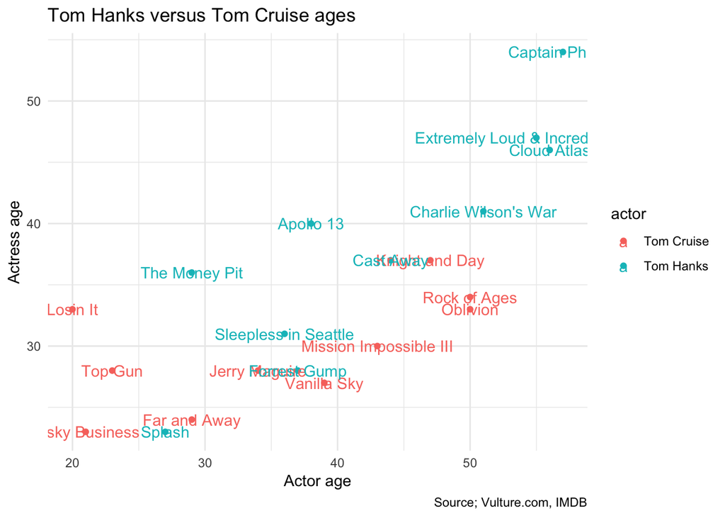

```r
ages <- read_csv("data/ages.csv")

# We'll focus on the movies from the Toms

# If you don't have dplyr or stringr installed yet, uncomment and run the lines below
#install.packages("dplyr")
#install.packages("stringr")

library(dplyr)
library(stringr)

toms <- ages %>%
  filter(str_detect(actor, "Tom"))

ggplot(data=toms,
       aes(x=actor_age,
           y=actress_age,
           color=actor,
           label=Movie)) +
      geom_point() +
      theme_minimal() +
      labs(y="Actress age", x="Actor age", title="Tom Hanks versus Tom Cruise ages", caption="Source; Vulture.com, IMDB") +
      geom_text()
```

This is one of the main criticisms of making charts programmatically. These labels look horrible. That creating charts via scripts requires exporting as an svg file and refining in Adobe Illustrator to make sure the labels look *just right*.

And I’m not saying you shouldn’t use whatever tool you want to make charts look perfect.

It’s just that the community understand these issues and are working together to come up with creative ways to handle it.

Let’s try the same code above with the new function `geom_text_repel()` from the **ggrepel** package.

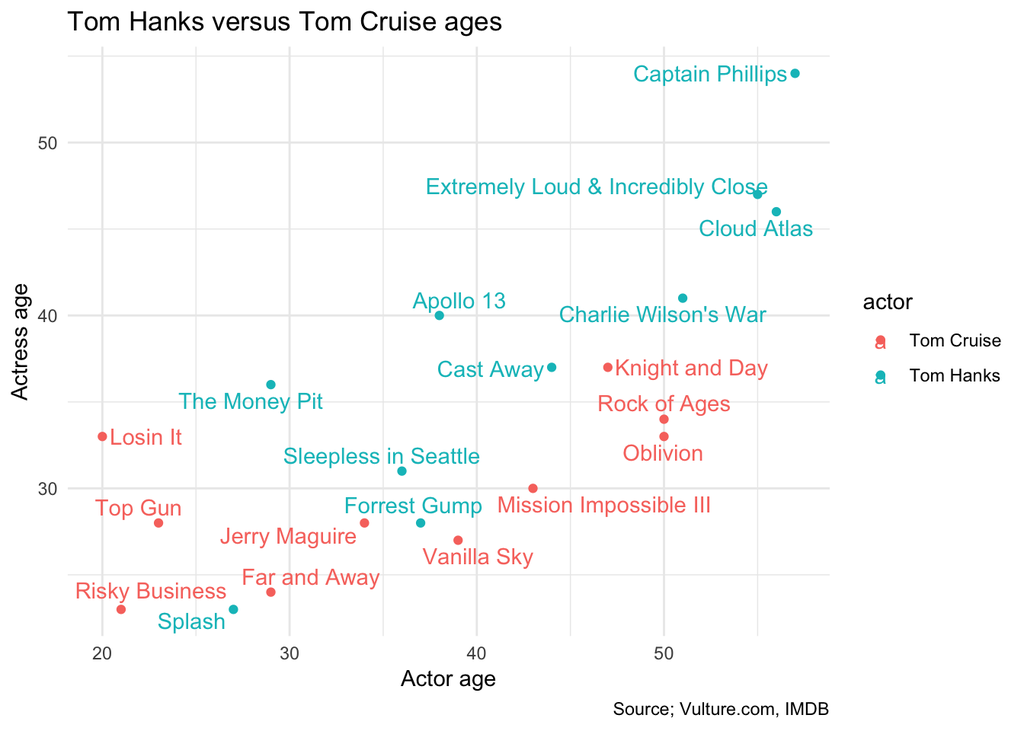

```r
# if you don't have the ggrepel package installed yet, uncomment and run the line below
#install.packages("ggrepel")

library(ggrepel)

ggplot(data=toms,
       aes(x=actor_age,
           y=actress_age,
           color=actor,
           label=Movie)) +
      geom_point() +
      theme_minimal() +
      labs(y="Actress age", x="Actor age", title="Tom Hanks versus Tom Cruise ages", caption="Source; Vulture.com, IMDB") +
      geom_text_repel()
```

Not bad for one line of code.

## ridgeplot

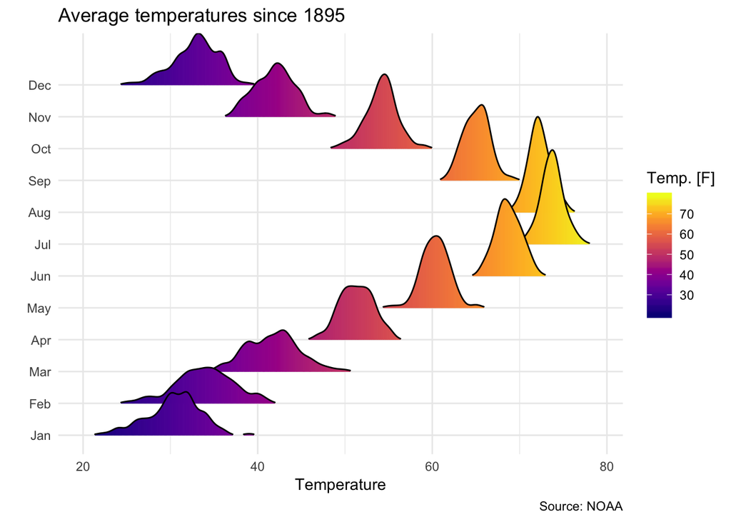

```r
# If you don't have ggridges or viridis installed yet, uncomment and run the lines below
#install.packages("ggridges")
#install.packages("viridis")

library(ggridges)
library(viridis)

ggplot(temps, aes(x=rounded_value, y=month_label, fill = ..x..)) +
  geom_density_ridges_gradient(scale=3, rel_min_height = 0.01) +
  scale_fill_viridis(name="Temp. [F]", option="C") +
  labs(title="Average temperatures since 1895", y="", x="Temperature", caption="Source: NOAA") +
  theme_minimal()
```

Neat. Let’s try it with the actor ages database.

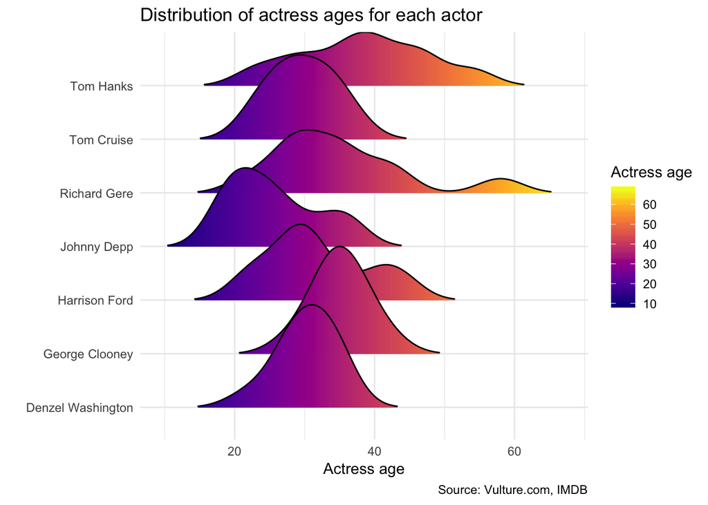

```r
ggplot(ages, aes(x=actress_age, y=actor, fill = ..x..)) +
  geom_density_ridges_gradient(scale=2, rel_min_height = 0.01) +
  scale_fill_viridis(name="Actress age", option="C") +
  labs(title="Distribution of actress ages for each actor", y="", x="Actress age", caption="Source: Vulture.com, IMDB") +
  theme_minimal()
```

## heatmap

You can make some interesting charts with `geom_tile()` and it’s already part of **ggplot2**, no extension needed. Let’s use [Global Land and Ocean Temperature Anomalies](https://www.ncdc.noaa.gov/cag/global/time-series) with respect to the 20th century average since 1880.

```r
anom <- read_csv("data/1880-2018.csv", skip=4)
head(anom)
```

```
## # A tibble: 6 x 2
##     Year Value
##    <int> <dbl>
## 1 188001  0
## 2 188002 -0.13
## 3 188003 -0.13
## 4 188004 -0.05
## 5 188005 -0.07
## 6 188006 -0.17
```

```r
anom$Date <- ymd(paste0(anom$Year, "01"))

# Extracting the year
anom$Year <- year(anom$Date)

# Extracting the month
anom$month <- month(anom$Date)
anom$month <- as.numeric(anom$month)
anom$month_label <- month(anom$Date, label=T)

# Turning the year into a factor so it'll chart easier
anom$Year <- as.factor(as.character(anom$Year))

library(forcats)

anom <- anom %>%
  mutate(Year=fct_rev(factor(Year)))
```

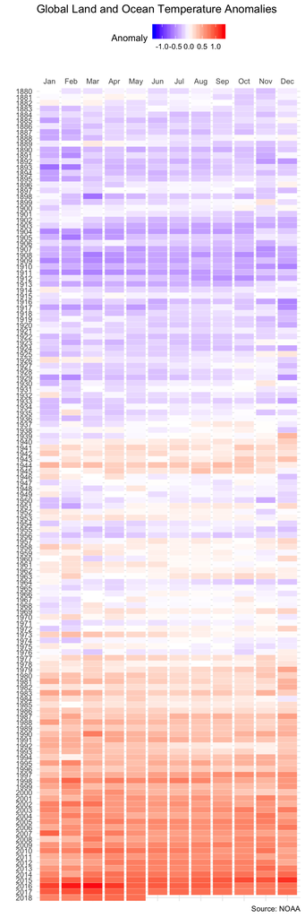

```r
ggplot(anom, aes(y=Year, x=month_label, fill=Value)) +
  geom_tile(color="white", width=.9, height=1.1) +
  theme_minimal() +
  scale_fill_gradient2(midpoint=0, low="blue", high="red", limits=c(-1.3, 1.3)) +
  labs(title="Global Land and Ocean Temperature Anomalies", x="", y="", caption="Source: NOAA", fill="Anomaly") +
  scale_x_discrete(position = "top") +
  theme(legend.position="top")
```

## Mr. Rogers

Did you know that someone sat down and identified the colors of [every single sweater](https://web.archive.org/web/20110525014454/http://neighborhoodarchive.blogspot.com/2011/05/sweater-colors.html) that Mr. Rogers wore?

Well, Owen Phillips scraped it with R and created and visualized it using **ggplot2**.

Check out his [well-documented code](https://github.com/Henryjean/Rogers-Cardigans/blob/master/MrRogers.R) thats hosted on Github.

In the meantime, you can recreate the chart by importing the csv below and then running the **ggplot2** functions.

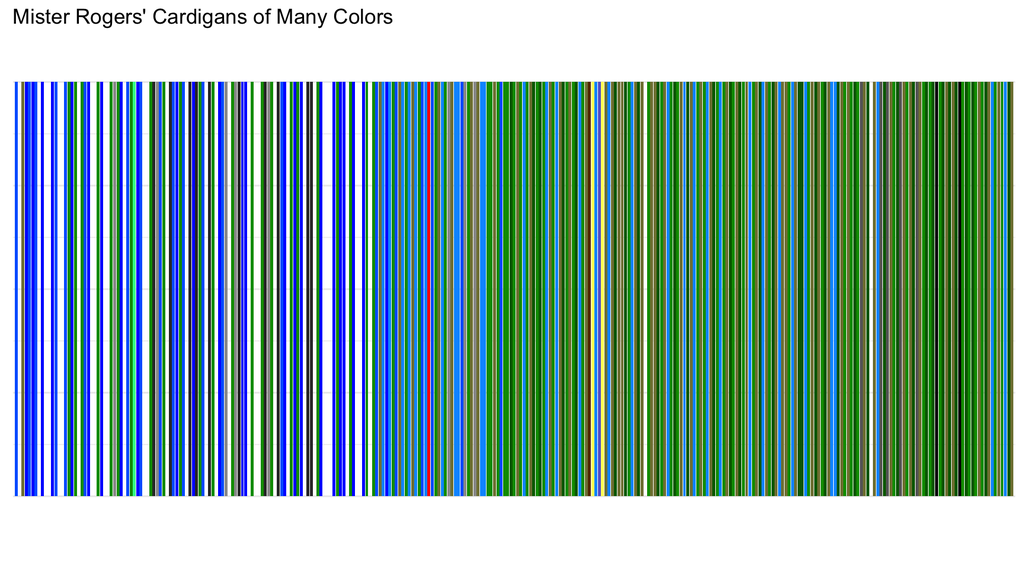

```r
# This code is pretty much from Owen Phillips

rogers <- read_csv("data/mrrogers.csv")
cn <- unique(rogers$colorcodes)


na.omit(rogers) %>% ggplot(aes(x=episodenumbers)) + geom_bar(aes(fill = factor(colorcodes))) +
  scale_fill_manual(values = cn) + theme_minimal() +
  labs(fill = "", x= "",
       title = "Mister Rogers' Cardigans of Many Colors",
       subtitle = " ",
       caption = "") +
  guides(fill=guide_legend(ncol=2)) +
  scale_x_discrete(breaks = c(1466, 1761),
                   labels = c("1979", "2001")) +
  theme(axis.title.y=element_blank(), axis.text.y=element_blank(), axis.ticks.y=element_blank()) +
  theme(legend.position = "none") + ylim(0,1)
```